# Using R to Analyze and Represent 3D Film Data

Madison Bradley, University of Calgary Mouse Performance Lab

R Wizardry (BIOL 607) Winter 2017

## Table of Contents

- Introduction
- Kinematic Analysis of Film Data
- Visual Representation
- Simple Statistical Analysis
- Session Info
- Literature Cited

# **Introduction**

## Background Information

Species that move by jumping have convergently evolved hind-limb elements (tibiae, tarsals, metatarsals) that are long relative to their body size and fore-limb length [1-7]. Jumping species are diverse, including frogs, locusts, kangaroos, and tarsiers [2-8]. It is assumed that limb elongation increases the time over which the muscles contract, thereby increasing acceleration and take-off velocity [2-6]. This assumption, however, has rarely been tested both between species and by comparing individuals with different limb lengths within a species [8,9].

Model organisms, such as mice, facilitate tightly controlled and repeatable studies of evolutionary hypotheses within a lab setting. The Longshanks (LS) mouse has been artificially selected to have a 15% longer tibia and a 10% longer femur with no change in body mass over 20 generations [10]. The LS model offers a unique opportunity to study variation within a single species at the population level as a model for how locomotor specializations can occur, while controlling for confounding factors such as nutrition, genetic background, body mass, and age. Ultimately, the maximal jumping performance (i.e. jump height) of the LS mice should be greater as a consequence of different musculoskeletal kinematics.

To quantitatively assess jumping performance, mice are trained from weaning to jump for a food reward to a raised platform within a filming enclosure. This training protocol ensures behavior is voluntary and standardized across individuals. High speed film is taken at 250 frames per second by three cameras with overlapping fields to gather precise three-dimensional spatial data of landmarked hind-limb joints and segments (Figure 1, Figure 2). The high-speed cameras are post-triggered, meaning that they continuously record until the desired locomotor behavior occurs and then the previous second of film is saved. This means the film sequence often needs to be cropped for standardization across individuals (more on that later).

[figure not shown]

> Figure 1. Filming set-up using three cameras with overlapping fields of view

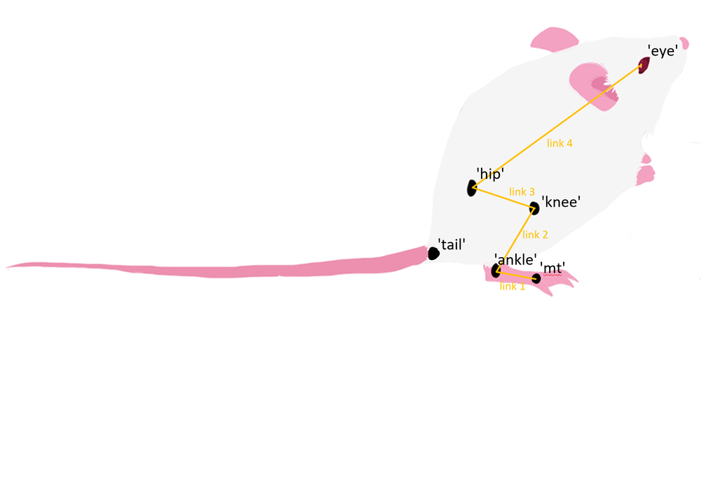

> Figure 2. Landmark placement on mouse hindlimb

Pairs of cameras can be calibrated in ProAnalyst using a calibration fixture that contains a physical matrix of known reference points. This calibration fixture is placed in the field of view of the cameras. Landmarks placed on the hindlimb of the mice are digitized in 3D space for each recorded frame. This data can then be used to calculate kinematic variables, such as: take-off duration, resultant take-off velocity, angular velocity, and angular acceleration. While ProAnalyst is a useful tool for digitization, it has limited analysis and visualization capabilities. Perhaps more importantly, it is a “black box” program. Only the input and output are manipulatable by the user while the underlying code and formulae are obscured. This tutorial proposes an alternative method for film analysis and data visualization using base R, an open source and open access coding language, as well as R packages that are openly available.

## Inputting Datasets

```r
#start session by clearing the clearing the environment
rm(list=ls(all=TRUE))
#check the current working directory
getwd()
#set the working directory to where the data sets are saved
setwd("C:/Users/Owner/Desktop/RWizardry/Final Project/coordinatedata")

#header is true because the first row is column names
##copy address of files from file explorer

#Control line mice

###Data for individual AC1
####jump 1, height = 15cm
ac1_1<-read.csv("file:///C:/Users/Owner/Desktop/RWizardry/Final Project/coordinatedata/AC_1_standardizeddata_seq1_15cm.csv", header=TRUE, check.names = FALSE)
###Data for individual CC1
####jump 1, height = 15cm
cc1_1<-read.csv("file:///C:/Users/Owner/Desktop/RWizardry/Final Project/coordinatedata/CC_1_standardizeddata_seq1_15cm.csv",header=TRUE, check.names = FALSE)

#Longshanks line 2 strain

###Data for individual P2
####jump 1, height = 15cm
p2_1<-read.csv("file:///C:/Users/Owner/Desktop/RWizardry/Final Project/coordinatedata/P2_1_standardizeddata_seq1_15cm.csv",header=TRUE, check.names = FALSE)

###Data for individual N2
####jump 1, height = 15cm

n2_1<-read.csv("file:///C:/Users/Owner/Desktop/RWizardry/Final Project/coordinatedata/P2_1_standardizeddata_seq1_15cm.csv",header=TRUE, check.names = FALSE)
```

Datasets ac1_1, cc1_1, p2_1, and n2_1 are now stored in the global environment. Use the head() and str() functions to get to know the datasets.

```r
str(ac1_1)
```

```
## 'data.frame':    21 obs. of  23 variables:
##  $ ï»¿FRAME : int  0 1 2 3 4 5 6 7 8 9 ...
##  $ HIP_X    : num  6.39 6.4 6.45 6.49 6.5 ...
##  $ HIP_Y    : num  4.36 4.26 4.29 4.3 4.12 ...
##  $ HIP_Z    : num  0.865 0.867 0.873 0.89 0.912 ...
##  $ KNEE_X   : num  7.46 7.46 7.48 7.53 7.55 ...
##  $ KNEE_Y   : num  4.23 4.06 4.06 4.1 3.9 ...
##  $ KNEE_Z   : num  0.676 0.668 0.666 0.665 0.639 ...
##  $ ANKLE_X  : num  6.87 6.87 6.86 6.87 6.83 ...
##  $ ANKLE_Y  : num  4.43 4.43 4.42 4.51 4.5 ...
##  $ ANKLE_Z  : num  -0.134 -0.134 -0.135 -0.128 -0.117 ...
##  $ MT_X     : num  7.3 7.3 7.31 7.33 7.2 ...
##  $ MT_Y     : num  3.16 3.16 3.24 3.35 3.11 ...
##  $ MT_Z     : num  -0.233 -0.233 -0.227 -0.214 -0.237 ...
##  $ EYE_X    : num  7.95 7.99 8.01 8.05 8.12 ...
##  $ EYE_Y    : num  2.68 2.68 2.57 2.55 2.61 ...
##  $ EYE_Z    : num  6.7 6.81 6.93 7.07 7.25 ...
##  $ TAIL_X   : num  4.1 4.31 4.31 4.29 4.25 ...
##  $ TAIL_Y   : num  3.3 3.87 3.88 3.75 3.52 ...
##  $ TAIL_Z   : num  -0.0601 -0.0253 -0.0313 -0.0469 -0.0499 ...
##  $ HIP_ANG  : num  83.3 83.2 83.9 85.4 87.7 ...
##  $ KNEE_ANG : num  62.8 62.1 61.3 60.8 59.6 ...
##  $ ANKLE_ANG: num  71.4 63.2 62.7 59.5 54.7 ...
##  $ TIME(S)  : num  0 0.004 0.008 0.012 0.016 0.02 0.024 0.028 0.032 0.036 ...
```

```r
head(ac1_1)
```

```
##   ï»¿FRAME    HIP_X    HIP_Y     HIP_Z   KNEE_X   KNEE_Y    KNEE_Z
## 1        0 6.393074 4.364006 0.8647090 7.463511 4.226108 0.6756082
## 2        1 6.398784 4.261342 0.8667965 7.463227 4.063454 0.6679368
## 3        2 6.447505 4.287115 0.8730848 7.484386 4.064445 0.6658427
## 4        3 6.494300 4.300343 0.8903905 7.531792 4.101878 0.6654214
## 5        4 6.498506 4.117766 0.9122095 7.546062 3.900818 0.6391650
## 6        5 6.567719 4.135962 0.9352797 7.560654 3.690521 0.6078022
##    ANKLE_X  ANKLE_Y     ANKLE_Z     MT_X     MT_Y       MT_Z    EYE_X
## 1 6.866809 4.433734 -0.13422728 7.296388 3.156582 -0.2329919 7.953974
## 2 6.866809 4.433734 -0.13422728 7.296388 3.156582 -0.2329919 7.993486
## 3 6.862681 4.421257 -0.13522922 7.308280 3.236857 -0.2266600 8.006600
## 4 6.874449 4.510844 -0.12818097 7.325212 3.353237 -0.2142706 8.051816
## 5 6.832642 4.497633 -0.11677603 7.195460 3.113450 -0.2373382 8.116080
## 6 6.792937 4.382550 -0.09998435 7.163723 3.164264 -0.2237956 8.156228
##      EYE_Y    EYE_Z   TAIL_X   TAIL_Y      TAIL_Z  HIP_ANG KNEE_ANG
## 1 2.683939 6.703932 4.097960 3.301162 -0.06010707 83.33072 62.81248
## 2 2.684388 6.810349 4.310290 3.873946 -0.02533740 83.20322 62.12567
## 3 2.574919 6.925419 4.312009 3.880119 -0.03132776 83.90452 61.28600
## 4 2.548055 7.069856 4.287840 3.747139 -0.04694083 85.39169 60.77411
## 5 2.606647 7.245466 4.253584 3.523100 -0.04985180 87.73244 59.56138
## 6 2.553297 7.456867 4.420121 3.875952  0.03900013 88.92823 53.90248
##   ANKLE_ANG TIME(S)
## 1  71.44844   0.000
## 2  63.17634   0.004
## 3  62.65914   0.008
## 4  59.46578   0.012
## 5  54.73233   0.016
## 6  49.53807   0.020
```

```r
#repeat for other datasets if need be
```

## Installing and Loading Packages

All packages are accessible from within R using the “install.packages()” function (see code).

### ggplot2

The ggplot2 package is used within this tutorial for layered plotting using ‘Grammar of Graphics’ syntax.

For further documentation visit: [ggplot CRAN](https://cran.r-project.org/web/packages/ggplot2/ggplot2.pdf)

### dplyr

The dplyr package is used within this tutorial for data manipulation. The dplyr syntax and use of pipes is at times more intuitive than that of base R, allowing for more efficient and understandable code.

For further documentation visit: [dyplr CRAN](https://cran.r-project.org/web/packages/dplyr/dplyr.pdf)

### linkR

Animal bodies have evolved to act as 3D lever systems with mechanical linkages and can thus be analyzed and represented as such. While there are many software packages available that can perform those functions, they are often prohibitively expensive and closed-source (like ProAnalyst). linkR is free, open-source, and allows for subsequent researchers to view the steps of analysis enabling replicability.

For further documentation visit: [linkR CRAN](https://cran.r-project.org/web/packages/linkR/linkR.pdf) and [linkR tutorial](https://aaronolsen.github.io/software/linkr/Modeling%20linkages%20using%20linkR%20v1.1.pdf)

### svgViewR

The svgViewR package is an important dependency of linkR. It enables the use to produce interactive 3D visualizations in .html file format. These .html files are viewable in compatible browsers such as: Firefox, Chrome, Safari (i.e. anything that is not Internet Explorer).

For further documentation visit: [svgViewR CRAN](https://cran.r-project.org/web/packages/svgViewR/svgViewR.pdf)

```r
#remove "#" in code to install packages from the CRAN repository (this only needs to be done once)

#install.packages("ggplot2")
#install.packages("dplyr")
#install.packages("linkR")
#install.packages("svgViewR")

#calling downloaded packages into the global environment
library(ggplot2)
library(dplyr)
library(svgViewR) #if you forget to load svgViewR, the most recent version of linkR will load it automatically
library(linkR)
```

# **Kinematic Analysis of Film Data**

In order to quantitatively describe the performance of the mouse jumps, we can perform kinematic analysis. Kinematics is essentially the geometry of motion and describes motion of objects without consideration of the forces acting on the system or the mass of the moving objects [11].

## Take-off time

First, a simple calculation to see how long it takes the mouse to leave the ground after initiating the behaviour. The film data is taken at 250 frames per second, so we can calculate the time interval and store it as an object.

```r
time.int<-1/250
time.int
```

```
## [1] 0.004
```

It’s possible to manually calculate the take-off time for each dataset, but the introduction of more typing equates to the introduction of more mistakes. Instead, let’s build a function using the same equation but make it more generalized by removing the specific names of the data sets and replacing it with a function parameter. Once the function is built, it can be used to create a vector of take-off times for all the individuals. This vector can then be combined with an vector of identifiers and a vector of strains of the same length using data.frame() to produce a data frame to be used later during statistical analysis.

```r
##can just calculate for each data set
(nrow(ac1_1)-5)*time.int
```

```
## [1] 0.064
```

```r
## or with a function
takeoff.time<- function(data){
  (nrow(data)-5)*time.int
}

#now let's calculate take off time for all of the individuals
times<-c(takeoff.time(ac1_1),takeoff.time(cc1_1),takeoff.time(n2_1),takeoff.time(p2_1))
indiv<-c("ac1","cc1","n2","p2")
strain<-as.factor(c("control","control","longshanks","longshanks"))

#use data.frame instead of cbind to make sure that the original types of data (i.e. numeric for the time and character otherwise) are maintained
takeoff.times<-data.frame(times,indiv,strain)
```

```
##   times indiv     strain
## 1 0.064   ac1    control
## 2 0.068   cc1    control
## 3 0.060    n2 longshanks
## 4 0.060    p2 longshanks
```

```
## 'data.frame':    4 obs. of  3 variables:
##  $ times : num  0.064 0.068 0.06 0.06
##  $ indiv : Factor w/ 4 levels "ac1","cc1","n2",..: 1 2 3 4
##  $ strain: Factor w/ 2 levels "control","longshanks": 1 1 2 2
```

## Take-off velocity

Take-off velocity is the resultant velocity as the mouse leaves the ground. This is calculated as the difference in position vector between the final frame and the immediately preceeding frame in cm/s. The dataset was manually cropped during digitization, so there are always 5 frames after take-off. To calculate take-off velocity, use the hip landmark. The hip is representative of the trajectory of the body as a whole because it is not a highly mobile landmark (as compared to the knee). This will be shown qualitatively later in the tutorial (Figure 4).

The formula used by this function is:

$$v _{takeoff} = \frac { ((x _{2} -x _{1} ) ^{2} +(y _{2} -y _{1} ) ^{2} + (z _{2} -z _{1} ) ^{2} ) ^{0.5} } { \Delta time}$$

In the following code, there are two examples of how to build this function dependent on the circumstance. All film sequences were taken at 250fps, so it is not necessary in this case to be able to toggle the time interval, but having a more flexible function may be useful for other cases. The output of this function can be put into a data frame for later using data.frame(), just like the take-off time example.

```r
#calculating take-off velocity for a single data set without a function
((((ac1_1[(nrow(ac1_1)-6),"HIP_X"]-ac1_1[(nrow(ac1_1)-5),"HIP_X"])^2)+((ac1_1[(nrow(ac1_1)-6),"HIP_Y"]-ac1_1[(nrow(ac1_1)-5),"HIP_Y"])^2)+((ac1_1[(nrow(ac1_1)-6),"HIP_Z"]-ac1_1[(nrow(ac1_1)-5),"HIP_Z"])^2))^0.5)/time.int


#they all have the same column names by default so we can make a function that only needs to take in the name of the data set.

takeoff.velocity<- function(data){
  ((((data[(nrow(data)-6),"HIP_X"]-data[(nrow(data)-5),"HIP_X"])^2)+((data[(nrow(data)-6),"HIP_Y"]-data[(nrow(data)-5),"HIP_Y"])^2)+((data[(nrow(data)-6),"HIP_Z"]-data[(nrow(data)-5),"HIP_Z"])^2))^0.5)/time.int
}

##flexible version of the function that allows full flexibility of parameters and allows for 2D analysis as well

takeoff.velocity.flex<- function(data,x,y,z=NULL,dtime){
  ((((data[(nrow(data)-6),x]-data[(nrow(data)-5),x])^2)+((data[(nrow(data)-6),y]-data[(nrow(data)-5),y])^2)+((data[(nrow(data)-6),z]-data[(nrow(data)-5),z])^2))^0.5)/dtime
}
```

```
##   v.takeoff indiv     strain
## 1  146.4105   ac1    control
## 2  198.4831   cc1    control
## 3  168.3141    n2 longshanks
## 4  168.3141    p2 longshanks
```

## Angular Velocity

Biomechanical angular velocity measures the angular rate of change of a body segment around a joint. When digitizing, it is possible to measure the angle of segments around a landmark (in this case, a joint) for each frame. It is then possible to find the angular velocity of a joint for the whole jump sequence. This is a useful measure in biomechanics because it assesses the velocity of extension and/or flexion of body segments, as well as the timing of peak angular velocity.

### Unstandardized Angular Velocity

This function uses the equation:

$$v_{ang} = \frac { \theta_{i + 1} - \theta_{ i}} { \Delta t }$$
where *i* is the angle in degrees and *t* is time measured in seconds.

It is considered “unstandardized” because it doesn’t account for different take-off times.

In order to quantify a curve of instaneous velocities through time, it will be necessary to build a for loop. To prevent future suffering, this for loop is nested within a function.

```r
angular_velocity<- function(data,joint1=NULL,joint2=NULL, joint3=NULL,time.int=0.004){
  joints<-c(joint1,joint2,joint3)
  ang_vel<-matrix(NA,nrow=nrow(data)-1,ncol=3,dimnames=list( NULL,c("Hip_Ang_Vel","Knee_Ang_Vel","Ankle_Ang_Vel")))
  idnum<-0
  for(j in joints){
    if(!is.null(j)){
      joint<-data[,j]
      idnum<-idnum+1
      for(i in 1:(nrow(data)-1)){
        ang_vel[i,idnum]<-(joint[i+1]-joint[i])/time.int
      }
    }
  }
  return(ang_vel)
}
```

The angular_velocity() function is able to take in a minimum of one joint and a maximum of three joints. The “time.int=” parameter is set to a default of 0.004 seconds because that is what suits the data, but it can be changed if necessary.

Before the first for loop within the function, a vector of the three joints needs to be created, as well as an empty matrix to hold the calculated values. The matrix must have one less number of rows than the original data set because it is comparing the difference between positions along a column.

The first for loop goes through each joint and passes to the second loop where the formula is housed. The if statement makes the function flexible by enabling it to recognize whether a joint parameter is null and if the first loop should loop through to another joint. The second (i.e. nested) for loop runs through the angles within the data set at position [i] and calculates the change between the angle at position [i] and the angle directly after [i+1].

```r
#use the angular_velocity function for all the data sets
ang_vel_ac1_1<-angular_velocity(data=ac1_1,joint1="HIP_ANG",joint2 = "KNEE_ANG",joint3 = "ANKLE_ANG")
ang_vel_cc1_1<-angular_velocity(data=cc1_1,joint1="HIP_ANG",joint2 = "KNEE_ANG",joint3 = "ANKLE_ANG")
ang_vel_n2_1<-angular_velocity(data=n2_1,joint1="HIP_ANG",joint2 = "KNEE_ANG",joint3 = "ANKLE_ANG")
ang_vel_p2_1<-angular_velocity(data=p2_1,joint1="HIP_ANG",joint2 = "KNEE_ANG",joint3 = "ANKLE_ANG")

## make results of all individuals into a four data frames using cbind() and time, individual and strain vectors

#AC1
ang_vel_ac1_1<-as.data.frame(ang_vel_ac1_1, stringsAsFactors=FALSE) #as.data.frame so that different types of data can be in it. the default output of the function is a matrix, which can only hold one type of data.
time<- seq(from=0.004,to=0.004*nrow(ang_vel_ac1_1),by=0.004)
individual<- rep("ac1",length=nrow(ang_vel_ac1_1))
Strain<- rep("control",length=nrow(ang_vel_ac1_1)) #use capital "S" because the object strain already exists in environment from earlier
ang_vel_ac1_1<-cbind(time,ang_vel_ac1_1,individual,Strain)
```

```
##     time Hip_Ang_Vel Knee_Ang_Vel Ankle_Ang_Vel individual  Strain
## 1  0.004   -31.87610    -171.7036    -2068.0241        ac1 control
## 2  0.008   175.32554    -209.9171     -129.3007        ac1 control
## 3  0.012   371.79228    -127.9730     -798.3402        ac1 control
## 4  0.016   585.18696    -303.1820    -1183.3607        ac1 control
## 5  0.020   298.94798   -1414.7239    -1298.5647        ac1 control
## 6  0.024   -94.33654   -1233.9798    -1064.1139        ac1 control
## 7  0.028  2460.09967    3203.0825     5537.3862        ac1 control
## 8  0.032  2489.58527   -1855.9727     3134.1946        ac1 control
## 9  0.036   976.06078    -554.3294     2038.2430        ac1 control
## 10 0.040  -957.86718    -994.3773     3765.3796        ac1 control
## 11 0.044  -191.75003    -450.6759     2055.1291        ac1 control
## 12 0.048  1408.16895    3244.7429     1387.6331        ac1 control
## 13 0.052  2264.74460    5483.1837      951.6171        ac1 control
## 14 0.056  1237.33000    2804.3287     5586.5328        ac1 control
## 15 0.060   494.86835     157.5166    -9544.2943        ac1 control
## 16 0.064  2191.26345    4581.3388    12060.0906        ac1 control
## 17 0.068   109.87055   -2849.6983    -4784.4793        ac1 control
## 18 0.072   537.98680    1620.8009     4790.1373        ac1 control
## 19 0.076 -3464.64553    -790.8963    -8538.8605        ac1 control
## 20 0.080 -7205.72895   -8649.1576    -8070.0815        ac1 control
```

```
## 'data.frame':    20 obs. of  6 variables:
##  $ time         : num  0.004 0.008 0.012 0.016 0.02 0.024 0.028 0.032 0.036 0.04 ...
##  $ Hip_Ang_Vel  : num  -31.9 175.3 371.8 585.2 298.9 ...
##  $ Knee_Ang_Vel : num  -172 -210 -128 -303 -1415 ...
##  $ Ankle_Ang_Vel: num  -2068 -129 -798 -1183 -1299 ...
##  $ individual   : Factor w/ 1 level "ac1": 1 1 1 1 1 1 1 1 1 1 ...
##  $ Strain       : Factor w/ 1 level "control": 1 1 1 1 1 1 1 1 1 1 ...
```

Repeat the above for individuals CC1, N2, and P2 (see full R script).

Join the four dataframes created for each individual using dyplr and the full_join() function. Using nested full_join() functions will keep all the information from all the input datasets. It is important that the dataframes are all structured the same and have the same column names. Use the str() function following full_join() to make sure the new data frame is structured correctly.

*Note: this will produce a warning message because the some of the columns used in the join are factors with different levels. In order to not lose any information, dyplr converts the factors to character values.*

```r
##join using dplyr

angular.velocity<- full_join(ang_vel_ac1_1,full_join(ang_vel_cc1_1,full_join(ang_vel_n2_1,ang_vel_p2_1)))
```

```
## 'data.frame':    79 obs. of  6 variables:
##  $ time         : num  0.004 0.008 0.012 0.016 0.02 0.024 0.028 0.032 0.036 0.04 ...
##  $ Hip_Ang_Vel  : num  -31.9 175.3 371.8 585.2 298.9 ...
##  $ Knee_Ang_Vel : num  -172 -210 -128 -303 -1415 ...
##  $ Ankle_Ang_Vel: num  -2068 -129 -798 -1183 -1299 ...
##  $ individual   : chr  "ac1" "ac1" "ac1" "ac1" ...
##  $ Strain       : chr  "control" "control" "control" "control" ...
```

### Standardized Angular Velocity

To directly compare the timing of the maximum angular velocities of different sequences, the sequences must be standardized. Each sequence has a different length of time, so the easiest way to standardize is to interpolate the values for each sequence from 0% to 100% of sequence length. To interpolate in R, use the approx() function. The approx() function gives an x and y output, where x is the position along the sequence and y is the interpolated angle value using a linear approximation.

```r
####using approx() function to interpolate from 0 to 100 %

approx(seq_along(ac1_1[,"HIP_ANG"]),ac1_1[,"HIP_ANG"],n=100)
```

```
## $x
##   [1]  1.000000  1.202020  1.404040  1.606061  1.808081  2.010101  2.212121
##   [8]  2.414141  2.616162  2.818182  3.020202  3.222222  3.424242  3.626263
##  [15]  3.828283  4.030303  4.232323  4.434343  4.636364  4.838384  5.040404
##  [22]  5.242424  5.444444  5.646465  5.848485  6.050505  6.252525  6.454545
##  [29]  6.656566  6.858586  7.060606  7.262626  7.464646  7.666667  7.868687
##  [36]  8.070707  8.272727  8.474747  8.676768  8.878788  9.080808  9.282828
##  [43]  9.484848  9.686869  9.888889 10.090909 10.292929 10.494949 10.696970
##  [50] 10.898990 11.101010 11.303030 11.505051 11.707071 11.909091 12.111111
##  [57] 12.313131 12.515152 12.717172 12.919192 13.121212 13.323232 13.525253
##  [64] 13.727273 13.929293 14.131313 14.333333 14.535354 14.737374 14.939394
##  [71] 15.141414 15.343434 15.545455 15.747475 15.949495 16.151515 16.353535
##  [78] 16.555556 16.757576 16.959596 17.161616 17.363636 17.565657 17.767677
##  [85] 17.969697 18.171717 18.373737 18.575758 18.777778 18.979798 19.181818
##  [92] 19.383838 19.585859 19.787879 19.989899 20.191919 20.393939 20.595960
```

[output cut: 18 more lines]

Rather than use the base approx() function for each joint of each individual sequence, let’s create an interpolate() function that will loop through a given data set and return a matrix of standarized values for each joint.

```r
# specify $y within the for loop because the $y output is all we want from the approx() function

interpolate<- function(data,joint1=NULL,joint2=NULL, joint3=NULL){
  joints<-c(joint1,joint2,joint3)
  inter<-matrix(NA,nrow=100,ncol=3,dimnames=list(NULL,c("Hip_Ang","Knee_Ang","Ankle_Ang")))
  idnum<-0
  for(j in joints){
    if(!is.null(j)){
      joint<-data[,j]
      idnum<-idnum+1
      inter[,idnum]<-approx(seq_along(joint),joint,n=100)$y
    }
  }
  return(inter)
}

int.ac1_1<-interpolate(ac1_1,"HIP_ANG","KNEE_ANG","ANKLE_ANG")
```

To save ourselves some trouble, let’s combine the angular_velocity() and interpolate() functions into a standardized.angular.velocity() function

This function uses the equation:

$$v_{ang} = \frac { \theta_{i + 1} - \theta_{ i}} { \Delta T }$$

where *i* is the angle in degrees and *T* is now a standardized percentage of time from 0-100%.

```r
# time interval needs to change because of the interpolation

standardized.angular.velocity<- function(data,joint.a=NULL,joint.b=NULL, joint.c=NULL,time.int=((nrow(data)-1)*0.004/100)){
  angular_velocity(data=(interpolate(data,joint.a,joint.b,joint.c)),joint1="Hip_Ang",joint2 = "Knee_Ang",joint3 = "Ankle_Ang",time.int = ((nrow(data)-1)*0.004/100))
}

stnd.ang.vel.ac1<-standardized.angular.velocity(ac1_1,"HIP_ANG","KNEE_ANG","ANKLE_ANG")
```

Repeat all the steps from unstandarized velocity to produce one large data frame (see full R script).

```r
str(stnd.angular.velocity)
```

```
## 'data.frame':    396 obs. of  6 variables:
##  $ percent      : int  1 2 3 4 5 6 7 8 9 10 ...
##  $ Hip_Ang_Vel  : num  -32.2 -32.2 -32.2 -32.2 -21.7 ...
##  $ Knee_Ang_Vel : num  -173 -173 -173 -173 -175 ...
##  $ Ankle_Ang_Vel: num  -2089 -2089 -2089 -2089 -1991 ...
##  $ individual   : chr  "ac1" "ac1" "ac1" "ac1" ...
##  $ Strain       : chr  "control" "control" "control" "control" ...
```

```r
head(stnd.angular.velocity)
```

```
##   percent Hip_Ang_Vel Knee_Ang_Vel Ankle_Ang_Vel individual  Strain
## 1       1   -32.19808    -173.4380    -2088.9133        ac1 control
## 2       2   -32.19808    -173.4380    -2088.9133        ac1 control
## 3       3   -32.19808    -173.4380    -2088.9133        ac1 control
## 4       4   -32.19808    -173.4380    -2088.9133        ac1 control
## 5       5   -21.73335    -175.3680    -1990.9979        ac1 control
## 6       6   177.09651    -212.0375     -130.6068        ac1 control
```

## Angular Acceleration

Since angular acceleration is the derivative of angular velocity, the angular_velocity() function can be easily tweaked to calculate angular acceleration using the equation:

$$a_{ang} = \frac { v_{\theta 2} - v_{ \theta 1}} { \Delta t }$$

See full R script for a complete treatment of angular acceleration, as it directly echoes the analytical procedure for angular velocity and will not be included in the tutorial.

```r
function(data,joint1=NULL,joint2=NULL, joint3=NULL,time.int=0.004){
  joints<-c(joint1,joint2,joint3)
  ang_acc<-matrix(NA,nrow=nrow(data)-1,ncol=3,dimnames=list(NULL,c("Hip_Ang_Acc","Knee_Ang_Acc","Ankle_Ang_Acc")))
  idnum<-0
  for(j in joints){
    if(!is.null(j)){
      joint<-data[,j]
      idnum<-idnum+1
      for(i in 1:(nrow(data)-1)){
        ang_acc[i,idnum]<-(joint[i+1]-joint[i])/time.int
      }
    }
  }
  return(ang_acc)
}
```

# **Visual Representation**

## Using linkR to produce an interactive jump sequence figure

Linkages are considered as a network of “links” or body elements such as a tibia or femur connected by joints (Figure 2). Each joint is able to permit a certain range of motions and their relative position is defined by a matrix of coordinates.

Programs such as ProAnalyst do not produce high quality, aesthetic figures and the figures are not interactive. linkR will create a 3D interactive visualization of joints and linkages in scalable vector graphics (svg) format using six steps. As an extension for future analyses, linkR can also be used to produce animations of linkages.

1. **Joint coordinates** : this is where the 3D coordinates of joints are defined within an object called joint.coords in order (metatarsal(x,y,z), ankle(x,y,z), knee(x,y,z), hip(x,y,z)), eye(x,y,z)).

To create Figures 3 and 4, the positions of five landmarks are repeated 4 times within the object (at time=0%, time=50%, time=75%, time=100%). For demonstration purposes the positions are translated so that y and z are switched to make it more intuitive to visualize. This will coerce the x axis to be a transverse section of the body, the y axis to be a sagittal section of the body, and the z axis to be a coronal section.

```r
#step 1: Joint coords

#make an object
## make it by hand using using values
##initial positions of joints
ac1_1[1,]

##position of joints at time=50%
ac1_1[nrow(ac1_1)/2,]

## position of joints at time=75%
ac1_1[0.75*nrow(ac1_1),]

##final position of joints
ac1_1[nrow(ac1_1),]

joint.coor<-rbind(c(7.29,-0.23,3.15),c(6.87,-0.13,4.43),c(7.46,0.67,4.22),c(6.39,0.86,4.36),c(7.95,6.70,2.68),c(7.01,-0.26,2.67),c(6.71,0.11,4.09),c(8.16,0.66,4.19),c(7.12,1.25,3.70),c(8.43,8.78,2.16),c(7.34,0.08,3.62),c(7.47,1.04,3.84),c(8.97,2.64,3.96),c(8.33,3.38,3.11),c(9.24,11.5,1.87),c(9.35,4.48,0.92),c(9.30,5.13,1.99),c(10.26,6.47,1.05),c(9.82,6.95,2.35),c(10.58,14.81,0.91))

## or make it using subsets
joint.coord<- rbind(c(ac1_1[1,"MT_X"],ac1_1[1,"MT_Z"],ac1_1[1,"MT_Y"]),
                    c(ac1_1[1,"ANKLE_X"],ac1_1[1,"ANKLE_Z"],ac1_1[1,"ANKLE_Y"]),
                    c(ac1_1[1,"KNEE_X"],ac1_1[1,"KNEE_Z"],ac1_1[1,"KNEE_Y"]),
                    c(ac1_1[1,"HIP_X"],ac1_1[1,"HIP_Z"],ac1_1[1,"HIP_Y"]),
                    c(ac1_1[1,"EYE_X"],ac1_1[1,"EYE_Z"],ac1_1[1,"EYE_Y"]),
                    c(ac1_1[0.5*nrow(ac1_1),"MT_X"],ac1_1[0.5*nrow(ac1_1),"MT_Z"],ac1_1[0.5*nrow(ac1_1),"MT_Y"]),
                    c(ac1_1[0.5*nrow(ac1_1),"ANKLE_X"],
                      ac1_1[0.5*nrow(ac1_1),"ANKLE_Z"],ac1_1[0.5*nrow(ac1_1),"ANKLE_Y"]),
                    c(ac1_1[0.5*nrow(ac1_1),"KNEE_X"],
                      ac1_1[0.5*nrow(ac1_1),"KNEE_Z"],ac1_1[0.5*nrow(ac1_1),"KNEE_Y"]),
                    c(ac1_1[0.5*nrow(ac1_1),"HIP_X"],
                      ac1_1[0.5*nrow(ac1_1),"HIP_Z"],ac1_1[0.5*nrow(ac1_1),"HIP_Y"]),
                    c(ac1_1[0.5*nrow(ac1_1),"EYE_X"],
                      ac1_1[0.5*nrow(ac1_1),"EYE_Z"],ac1_1[0.5*nrow(ac1_1),"EYE_Y"]),
                    c(ac1_1[0.75*nrow(ac1_1),"MT_X"],
                      ac1_1[0.75*nrow(ac1_1),"MT_Z"],ac1_1[0.75*nrow(ac1_1),"MT_Y"]),
                    c(ac1_1[0.75*nrow(ac1_1),"ANKLE_X"],
                      ac1_1[0.75*nrow(ac1_1),"ANKLE_Z"],ac1_1[0.75*nrow(ac1_1),"ANKLE_Y"]),
                    c(ac1_1[0.75*nrow(ac1_1),"KNEE_X"],
                      ac1_1[0.75*nrow(ac1_1),"KNEE_Z"],ac1_1[0.75*nrow(ac1_1),"KNEE_Y"]),
                    c(ac1_1[0.75*nrow(ac1_1),"HIP_X"],
                      ac1_1[0.75*nrow(ac1_1),"HIP_Z"],ac1_1[0.75*nrow(ac1_1),"HIP_Y"]),
                    c(ac1_1[0.75*nrow(ac1_1),"EYE_X"],
                      ac1_1[0.75*nrow(ac1_1),"EYE_Z"],ac1_1[0.75*nrow(ac1_1),"EYE_Y"]),
                    c(ac1_1[nrow(ac1_1),"MT_X"],ac1_1[nrow(ac1_1),"MT_Z"],ac1_1[nrow(ac1_1),"MT_Y"]),
                    c(ac1_1[nrow(ac1_1),"ANKLE_X"],ac1_1[nrow(ac1_1),"ANKLE_Z"],ac1_1[nrow(ac1_1),"ANKLE_Y"]),
                    c(ac1_1[nrow(ac1_1),"KNEE_X"],ac1_1[nrow(ac1_1),"KNEE_Z"],ac1_1[nrow(ac1_1),"KNEE_Y"]),
                    c(ac1_1[nrow(ac1_1),"HIP_X"],ac1_1[nrow(ac1_1),"HIP_Z"],ac1_1[nrow(ac1_1),"HIP_Y"]),
                    c(ac1_1[nrow(ac1_1),"EYE_X"],ac1_1[nrow(ac1_1),"EYE_Z"],ac1_1[nrow(ac1_1),"EYE_Y"]))
```

2. **Joint types** : There are four possible joint types that must be defined using a vector in the same order as the joint coordinates.
- Linear (L): permits translation along a single vector
- Planar (P): permits translation within a plane
- Rotational (R): permits rotation along a single axis
- Spherical (S): permits rotation along all 3 axes.

These joint types can, but do not necessarily, mirror the biological terminology for the type of joint. For example, the femoral head/acetabulum junction at the hip is a ‘ball in socket’ joint with a spherical component, and it functions as a spherical joint in linkR. The knee and ankle act as a rotational joints in linkR, though they are commonly referred to as hinge joints. The remaining joints landmarked within the data set are considered spherical type in linkR because they have x, y, and z components of movement.

```r
#step 2:joint types
joint.types <- c("S", "R", "R", "S", "S","S", "R", "R", "S", "S","S", "R", "R", "S", "S","S", "R", "R", "S", "S")
```

3. **Joint constraints** : Constraints are a description of the direction of motion permitted by a joint and are defined as a vector that is in the same order as the joint type vector. A linear joint is constrained by the line it moves along, a planar joint is constrained by the perpendicular vector to its action, and a rotational joint is constrained by the axis of rotion. Spherical joints permit motion in all directions and the constraint is set to NA.

```r
#step 3: joint contraints
#use list() instead of cbind() because there are different types of data included
#the only important contraint is about the hip joint
#1 in the z axis because hip and knee can't move independently in the z axis
joint.cons <- list(NA, c(0,0,1), c(0,0,1), NA, NA,NA, c(0,0,1), c(0,0,1), NA, NA,NA, c(0,0,1), c(0,0,1), NA, NA,NA, c(0,0,1), c(0,0,1), NA, NA)
```

4. **Joint connections** : Each joint can connect two links. The two links connected by a joint are specified in a two column matrix in which each column corresponds to a link and each row corresponds to a joint. Thus, the matrix should be in the same order and have the same number of rows as the joint coordinate matrix. The links in this example are defined as follows (Figure 2):
- link 0 = “ground”
- link 1,5,9,13 = foot
- link 2,6,10,14 = tibia and fibula
- link 3,7,11,15 = femur
- link 4,8,12,16 = “body”

```r
#step 4: Joint connections
joint.conn<- rbind(c(0,1), c(1,2), c(2,3), c(3,4),c(4,0),c(0,5), c(5,6), c(6,7), c(7,8),c(8,0),c(0,9), c(9,10), c(10,11), c(11,12),c(12,0),c(0,13), c(13,14), c(14,15), c(15,16),c(16,0))
```

5. **Defining linkages** : Using the defineLinkage() function make an object that assigns the objects from the previous four steps.

```r
#step 5: define linkages using the "defineLinkage" function
#basically plug in the names of objects that you made in previous 4 steps

linkage<- defineLinkage(joint.coor = joint.coord, joint.types = joint.types, joint.cons = joint.cons, joint.conn = joint.conn)
```

6. **Drawing linkages** : using the drawLinkage() function there are two methods to produce a stick figure plot, in 2D and in 3D respectively.

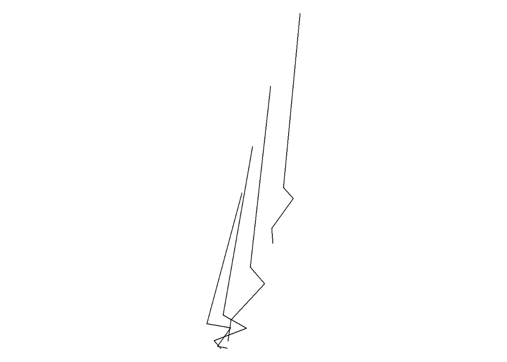

```r
#step 6: visualize linkage using the "drawLinkage" function

#if you change the method to 'plot' the function will print a 2D plot
#joint.cex=0 gets rid of joint points and looks nicer
drawLinkage(linkage, method=plot, joint.cex=0)
```

> Figure 3. A stick figure plot produced by linkR passing through to the base R plotting function showing a body of a mouse while jumping in lateral view at time=0%, time=50%, time=75%, and time=100%.

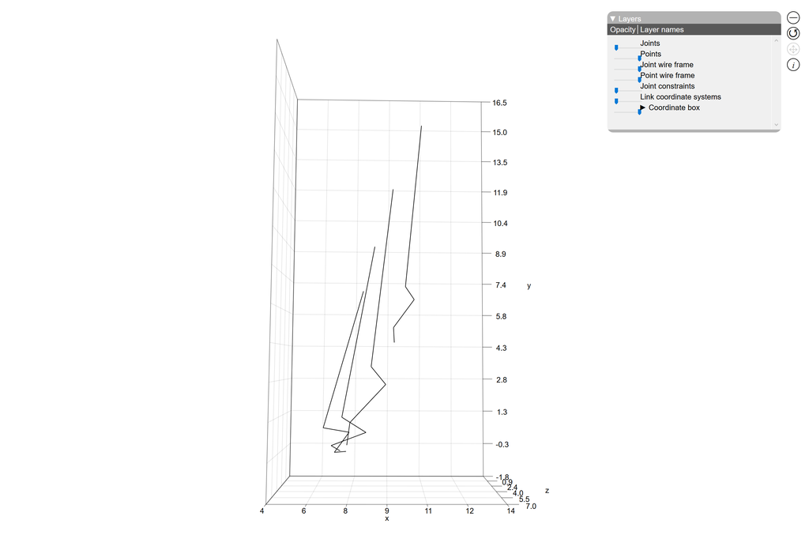

```r
drawLinkage(linkage, file='jumping sequence 2')
#default method is an .html file saved to the working directory
```

> Figure 4. Output of linkR functions as viewed in a web browser using svgViewR showing a stick drawing of the body of a mouse jumping in lateral view at time=0%, time=50%, time=75%, and time=100%

### svgViewR commands

Once the .html file produced by linkR that is saved in the working directory is opened in a browser, svgViewR takes over. Some helpful keyboard commands that svgViewR uses are:

- **‘j’** zoom out
- **‘z’** zoom in
- **‘r’ + click + drag** rotates figure

The .html figure ‘jumping sequence’ can be used for qualitative descriptions of the body position of the mouse through time. It is especially useful for descriptions of how joints are positioned relative to each other. In the case of the ac1 jump sequence (provided as an .html file), you can see that the knee joint flares out from the midline of the body (in a positive z direction) at times 50% and 75% prior to take-off and then comes in to be inline with the midline of the body post take-off at time 100%.